# Chemical Properties Influencing Red Wine Quality

A Project for Exploratory Data Analysis with R

## Introduction

This report explores various chemical properties that could influence red wine’s quality.

The data set is sourced from:

P. Cortez, A. Cerdeira, F. Almeida, T. Matos and J. Reis.  
Modeling wine preferences by data mining from physicochemical properties.  
In Decision Support Systems, Elsevier, 47(4):547-553. ISSN: 0167-9236.

Available at:  
[@Elsevier] http://dx.doi.org/10.1016/j.dss.2009.05.016  
[Pre-press (pdf)] http://www3.dsi.uminho.pt/pcortez/winequality09.pdf  
[bib] http://www3.dsi.uminho.pt/pcortez/dss09.bib

### Overview of Data Set

```
## 'data.frame':    1599 obs. of  13 variables:
##  $ X                   : int  1 2 3 4 5 6 7 8 9 10 ...
##  $ fixed.acidity       : num  7.4 7.8 7.8 11.2 7.4 7.4 7.9 7.3 7.8 7.5 ...
##  $ volatile.acidity    : num  0.7 0.88 0.76 0.28 0.7 0.66 0.6 0.65 0.58 0.5 ...
##  $ citric.acid         : num  0 0 0.04 0.56 0 0 0.06 0 0.02 0.36 ...
##  $ residual.sugar      : num  1.9 2.6 2.3 1.9 1.9 1.8 1.6 1.2 2 6.1 ...
##  $ chlorides           : num  0.076 0.098 0.092 0.075 0.076 0.075 0.069 0.065 0.073 0.071 ...
##  $ free.sulfur.dioxide : num  11 25 15 17 11 13 15 15 9 17 ...
##  $ total.sulfur.dioxide: num  34 67 54 60 34 40 59 21 18 102 ...
##  $ density             : num  0.998 0.997 0.997 0.998 0.998 ...
##  $ pH                  : num  3.51 3.2 3.26 3.16 3.51 3.51 3.3 3.39 3.36 3.35 ...
##  $ sulphates           : num  0.56 0.68 0.65 0.58 0.56 0.56 0.46 0.47 0.57 0.8 ...
##  $ alcohol             : num  9.4 9.8 9.8 9.8 9.4 9.4 9.4 10 9.5 10.5 ...
##  $ quality             : int  5 5 5 6 5 5 5 7 7 5 ...
```

```
##        X          fixed.acidity   volatile.acidity  citric.acid
##  Min.   :   1.0   Min.   : 4.60   Min.   :0.1200   Min.   :0.000
##  1st Qu.: 400.5   1st Qu.: 7.10   1st Qu.:0.3900   1st Qu.:0.090
##  Median : 800.0   Median : 7.90   Median :0.5200   Median :0.260
##  Mean   : 800.0   Mean   : 8.32   Mean   :0.5278   Mean   :0.271
##  3rd Qu.:1199.5   3rd Qu.: 9.20   3rd Qu.:0.6400   3rd Qu.:0.420
##  Max.   :1599.0   Max.   :15.90   Max.   :1.5800   Max.   :1.000
##  residual.sugar     chlorides       free.sulfur.dioxide
##  Min.   : 0.900   Min.   :0.01200   Min.   : 1.00
##  1st Qu.: 1.900   1st Qu.:0.07000   1st Qu.: 7.00
##  Median : 2.200   Median :0.07900   Median :14.00
##  Mean   : 2.539   Mean   :0.08747   Mean   :15.87
##  3rd Qu.: 2.600   3rd Qu.:0.09000   3rd Qu.:21.00
##  Max.   :15.500   Max.   :0.61100   Max.   :72.00
##  total.sulfur.dioxide    density             pH          sulphates
##  Min.   :  6.00       Min.   :0.9901   Min.   :2.740   Min.   :0.3300
##  1st Qu.: 22.00       1st Qu.:0.9956   1st Qu.:3.210   1st Qu.:0.5500
##  Median : 38.00       Median :0.9968   Median :3.310   Median :0.6200
##  Mean   : 46.47       Mean   :0.9967   Mean   :3.311   Mean   :0.6581
##  3rd Qu.: 62.00       3rd Qu.:0.9978   3rd Qu.:3.400   3rd Qu.:0.7300
##  Max.   :289.00       Max.   :1.0037   Max.   :4.010   Max.   :2.0000
##     alcohol         quality
##  Min.   : 8.40   Min.   :3.000
##  1st Qu.: 9.50   1st Qu.:5.000
##  Median :10.20   Median :6.000
##  Mean   :10.42   Mean   :5.636
##  3rd Qu.:11.10   3rd Qu.:6.000
##  Max.   :14.90   Max.   :8.000
```

The dataset contains 1,599 entries of red wine, each with 12 variables comprising 11 measured chemical properties and 1 subjective grading of the wine’s quality.

## Univariate Plots

### Histogram of Quality

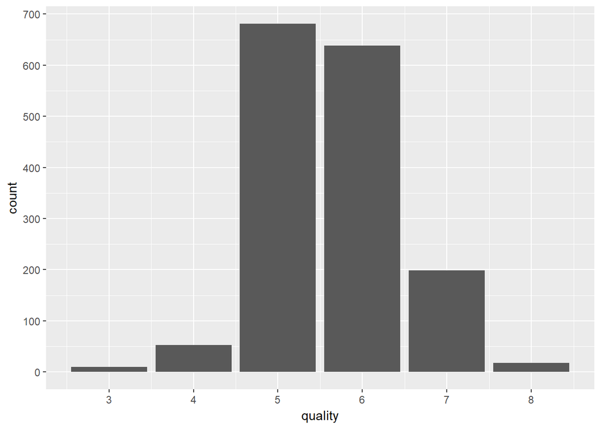

**Observation(s):**

### Grouping of Quality Scores

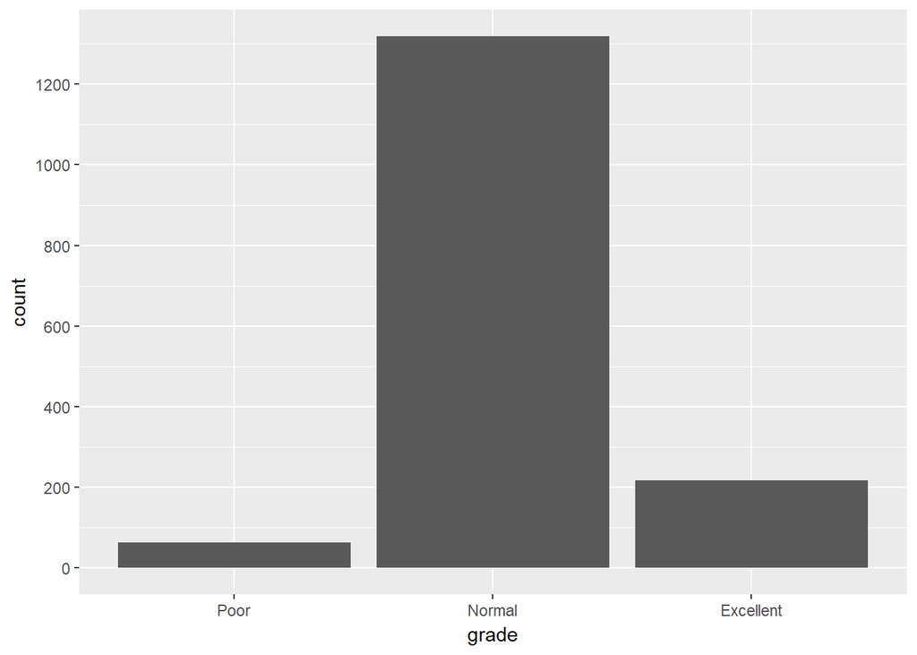

```
## # A tibble: 3 x 3
##   grade         n percentage
##   <fct>     <int> <chr>
## 1 Poor         63 3.94%
## 2 Normal     1319 82.5%
## 3 Excellent   217 13.6%
```

**Observation(s):**  
The red wine dataset is heavily represented by Normal grade quality score, with over 82% of wines being scored as such.

### Fixed Acidity

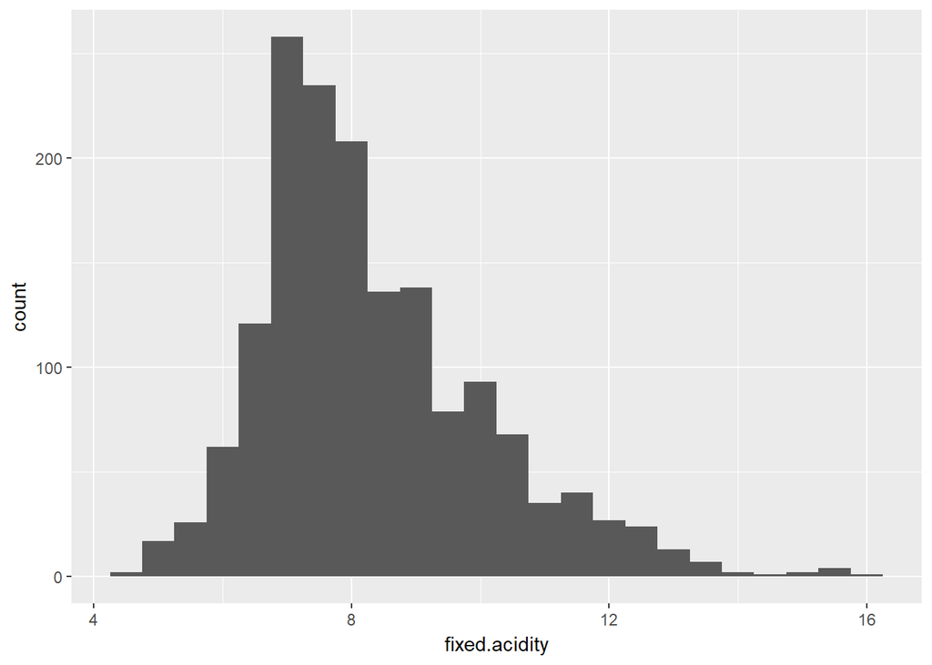

**Observation(s):**  
Normal distribution with positive skew and possible outliers after “14” on x-axis.

### Volatile Acidity

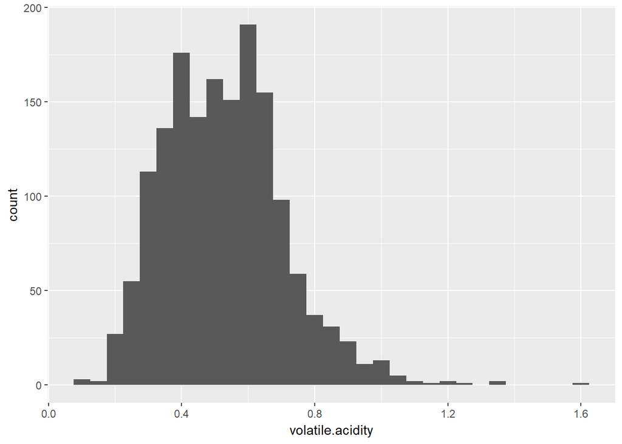

**Observation(s):**  
Normal distribution with positive skew and possible outliers after “1.1” on x-axis.

### Citric Acid

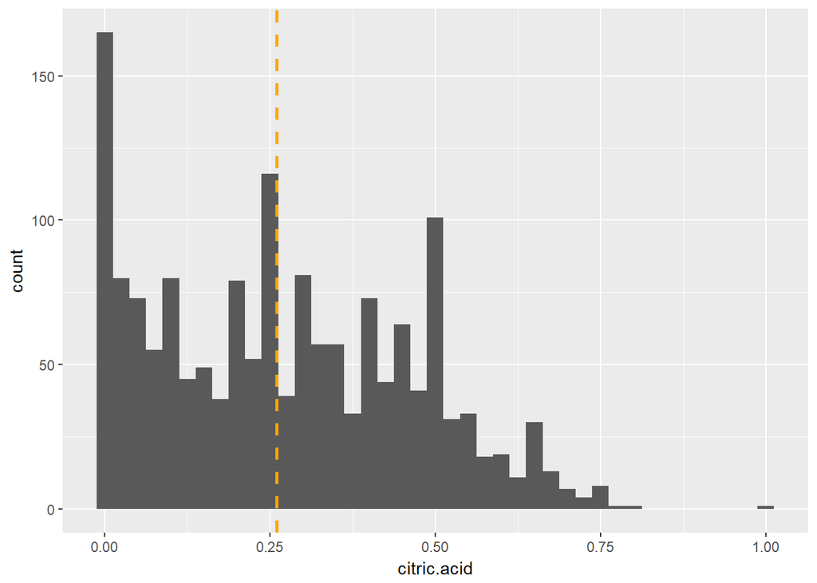

```
##    Min. 1st Qu.  Median    Mean 3rd Qu.    Max.
##   0.000   0.090   0.260   0.271   0.420   1.000
```

**Observation(s):**  
Multi-modal distribution of samples across the range of citric acid. The  
dashed line represents the median value from the data set. It would be interesting to observe how this property exhibits itself across the different quality grades.

### Residual sugar

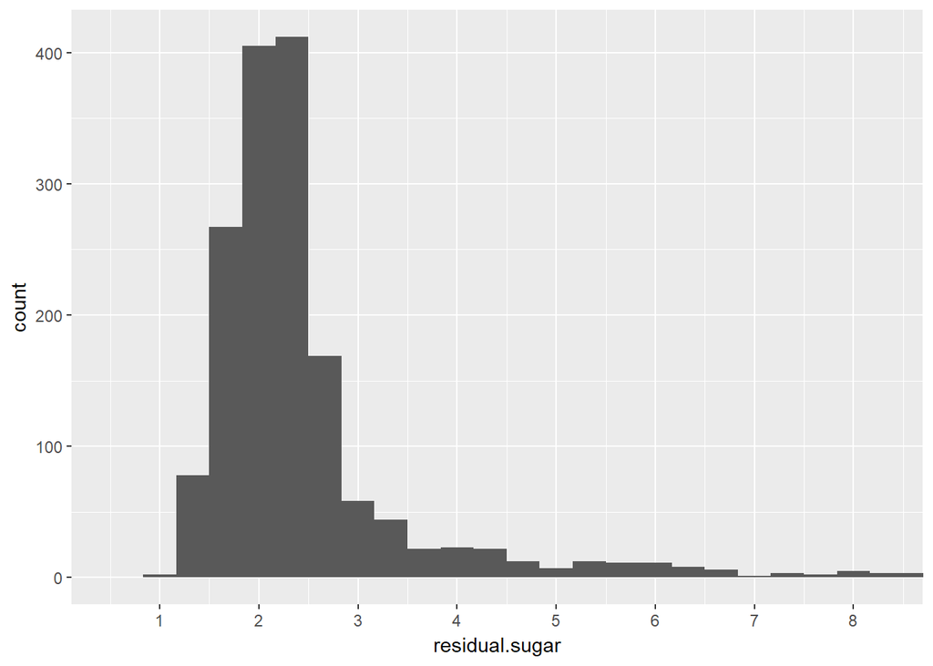

**Observation(s):**  
Normal distribution that is positively skewed, and is a candidate for application of log transformation.

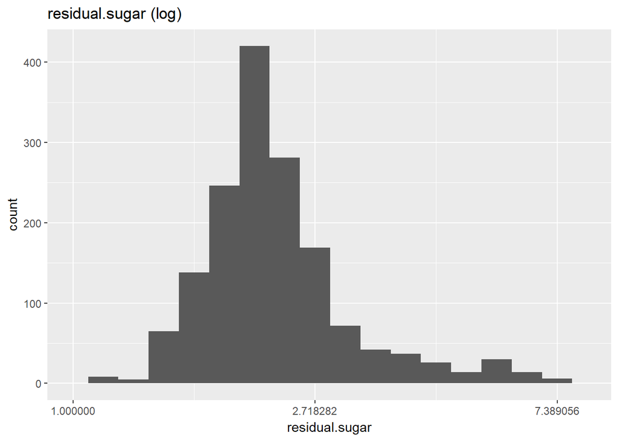

**Observation(s):**  
A more normal distribution after log transformation.

### Chlorides

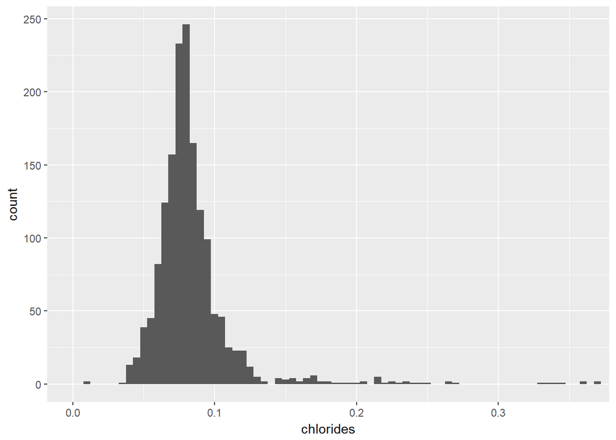

**Observation(s):**  
Normal distribution that is postively skewed. Outliers filtered out by limiting plot to points with 99% quantile, yet long-tail still exists.

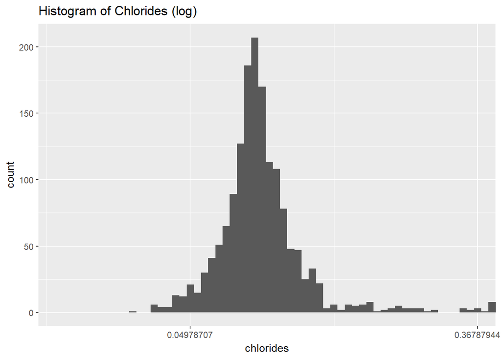

**Observation(s):**  
Normal distribution with long tail after log transformation.

### Free SO2

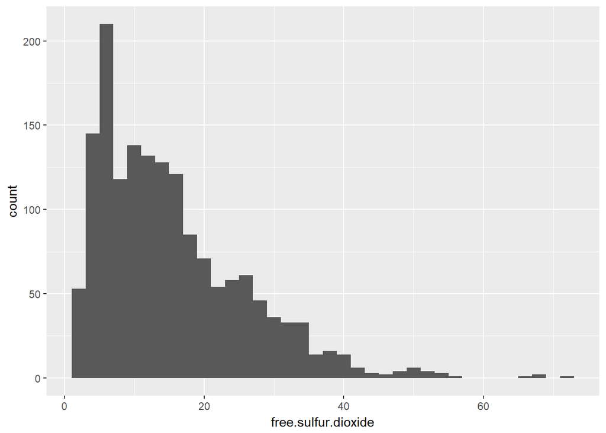

**Observation(s):**  
This positively skewed plot almost has a log normal distribution.

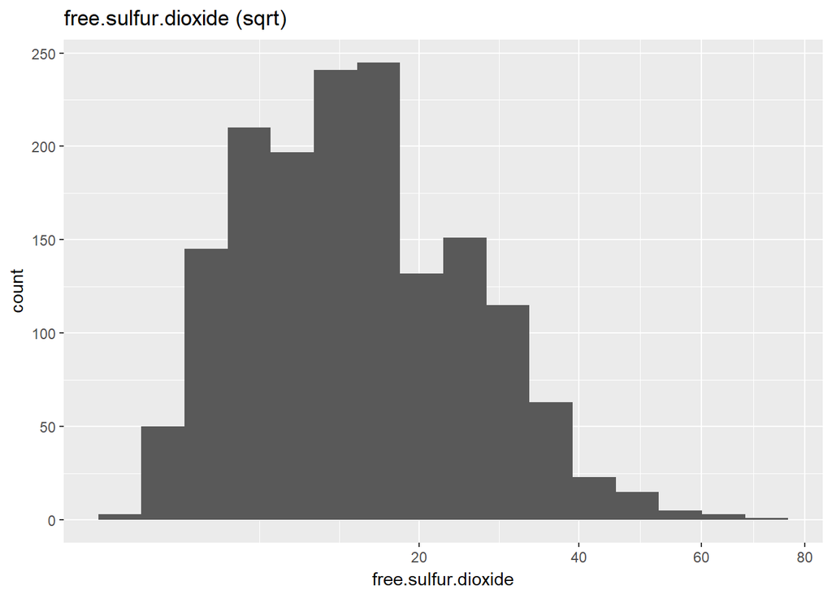

**Observation(s):**  
Transformed plot using square-root has a more normal distribution.

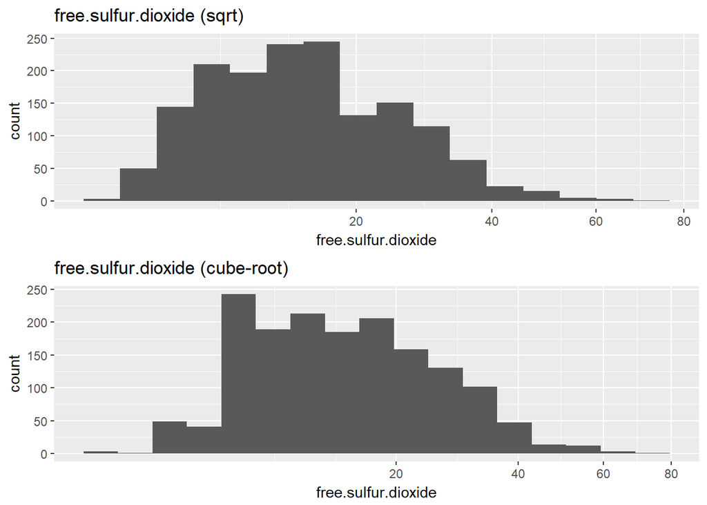

**Observation(s):**  
Applying cube-root transformation did not improve the distribution.

### Total SO2

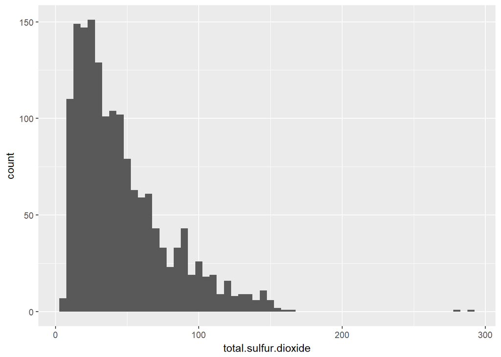

**Observation(s):**  
This positively skewed plot almost has a log normal distribution, and resembles the shape of plot for “free sulfur dioxide”.

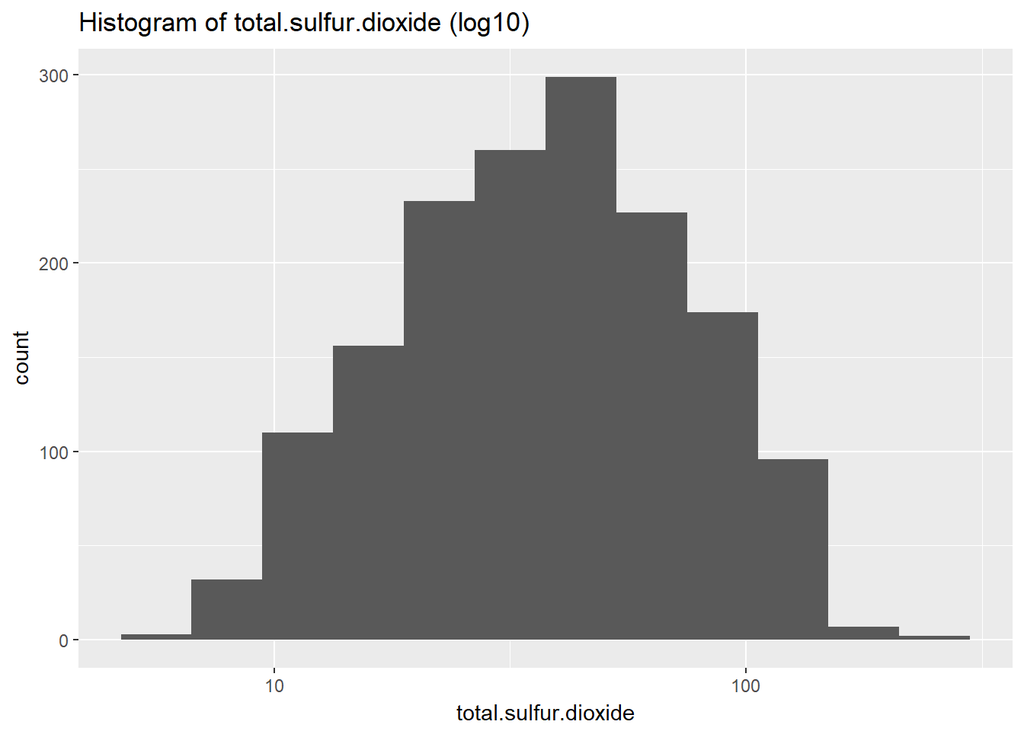

**Observation(s):**  
Transformed plot using log10 gives a normal distribution.

### Density

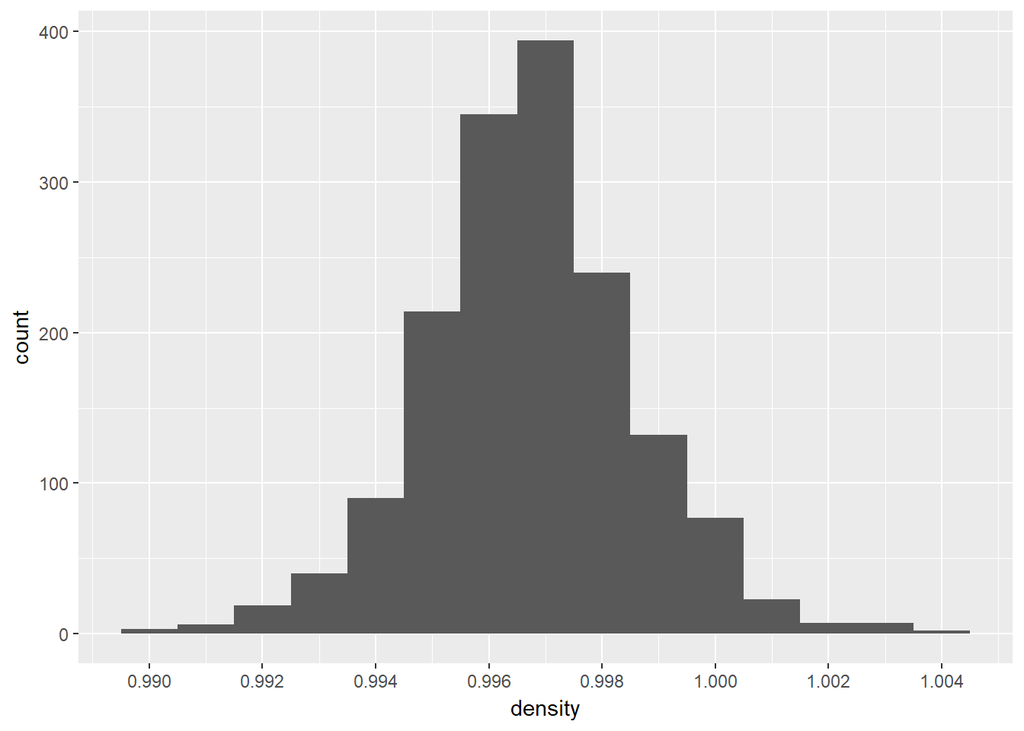

**Observation(s):**  
Normal distribution.

### pH

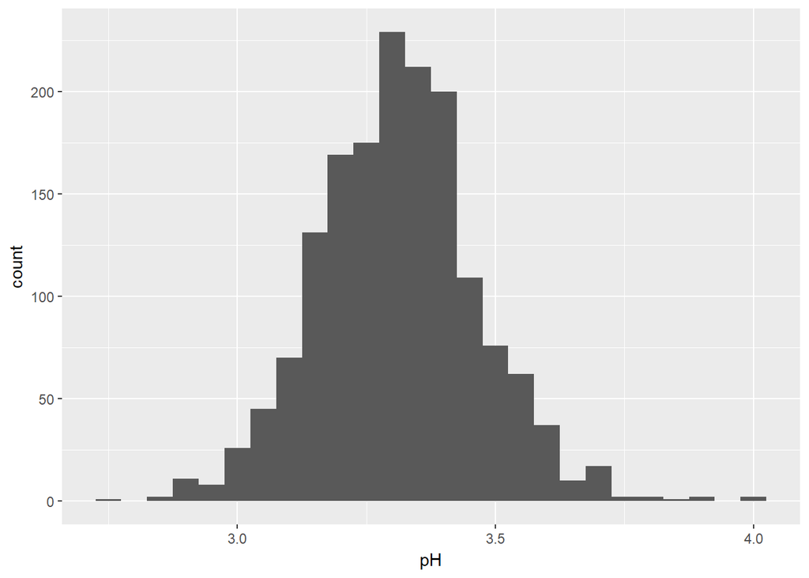

**Observation(s):**  
Normal distribution.

### Sulphates

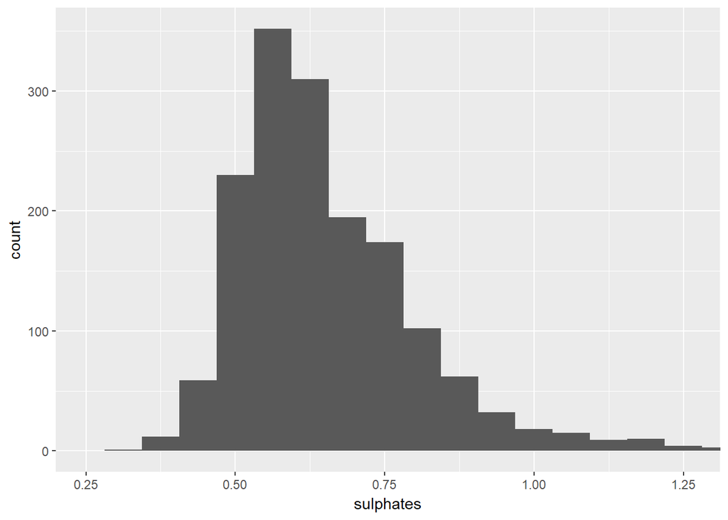

**Observation(s):**  
This positively skewed plot almost has a log normal distribution, and long-tail spread (even after filtering data points beyond the 99% quantile).

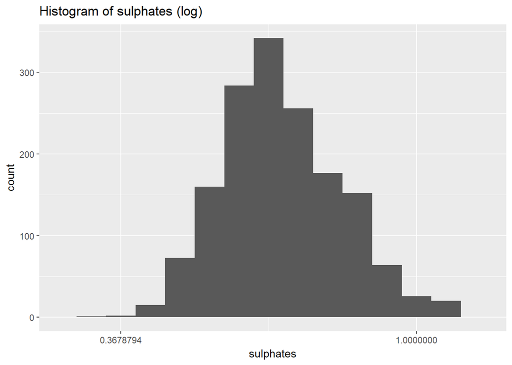

**Observation(s):**  
Normal distribution after transforming with log and removing points beyond 99% quantile.

### Alcohol

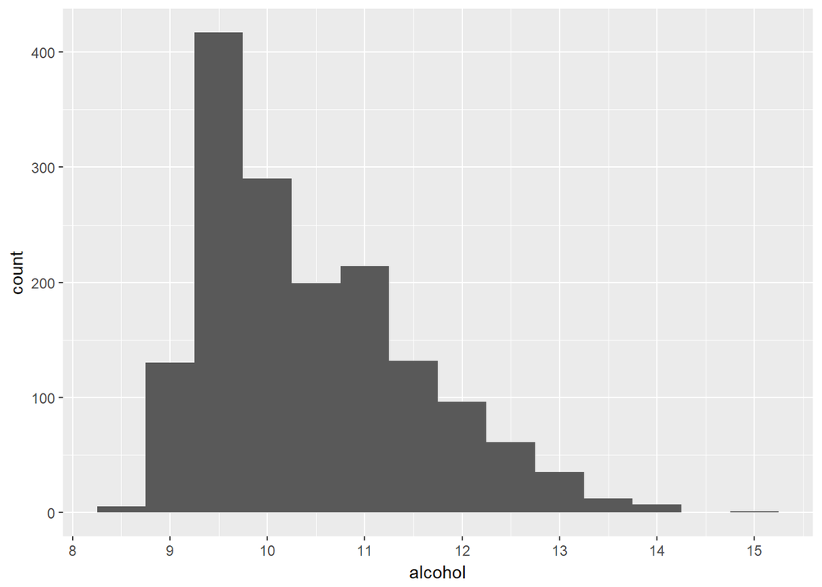

**Observation(s):**  
Positively skewed normal distribution plot.

## Univariate Analysis

### What is the structure of your dataset?

Dataset of red wine has 1,599 observations with 13 variables. 11 of those variables represent measured chemical properties in the wine, and 1 represents subjective quality score given by wine experts. The remaining variable represents a numbering sequence for entries in the dataset.

### What is/are the main feature(s) of interest in your dataset?

Quality score and citric acid concentrtion are the main features of interest.

The distribution of citric acid is multi-modal, and I’d like to see how this ties in with quality score. Citric acid concentration is said to give wine a fruity flavour.

### What other features in the dataset do you think will help support your investigation into your feature(s) of interest?

I think alcohol and sulphates could contribute to the variation of quality.

### Did you create any new variables from existing variables in the dataset?

I created a new variable called “grade” to represent the grouping of “quality” scores.

The quality score of wines in dataset range from 3 to 8. The distribution of quality scores suggest that wines can be broadly grouped into Poor, Normal, Excellent grades where:

1. Poor has quality score 3 - 4
2. Normal has quality score 5 - 6
3. Excellent has quality socre 7 - 8

The revised grading can help enhance visualization with respect to wine quality by reducing information overload.

### Of the features you investigated, were there any unusual distributions? Did you perform any operations on the data to tidy, adjust, or change the form of the data? If so, why did you do this?

Yes, several properties had histograms that were skewed (positively), which benefitted from transformation and cut-off (at 99% quantile) to produce a more normal distribution.

Between histograms of all chemical properties, the “citric.acid” histogram must be the most unusual with its multi-modal distribution.

Posts in [StackExchange](https://stats.stackexchange.com/questions/209241/what%20-transformation-should-i-use-for-a-bimodal-distribution) suggested that monotonic transformation may not be useful in this case.

## Bivariate Plots

Creating a scatter plot matrix with “grade” and omitting “quality” to catch a quick glimpse of relationships between different variables.

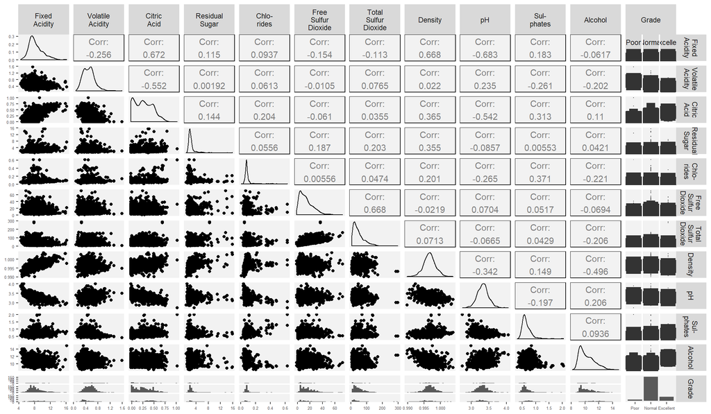

**Observation(s):**  
Citric Acid has interesting correlation with:  
1. Density (r = 0.36)  
2. Sulphates (r = 0.31)

No further exploration of citric acid against fixed acidity and volatile acidity is taken, partly because of the relatively higher correlation (> 0.5). Due to this correlation, it stands to reason that the change in citric acid concentration will be accompanied by a corresponding change in those 2 properties.

### Citric Acid by Grade

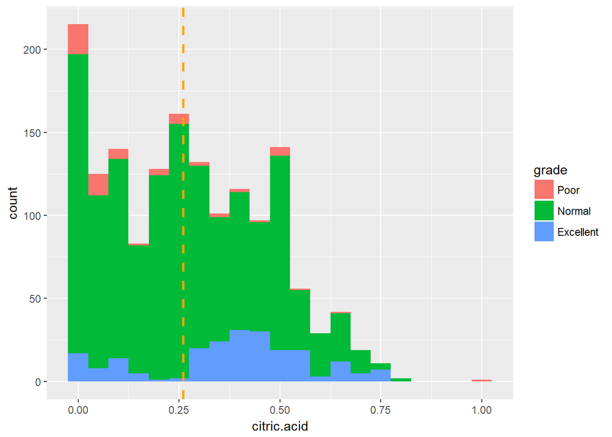

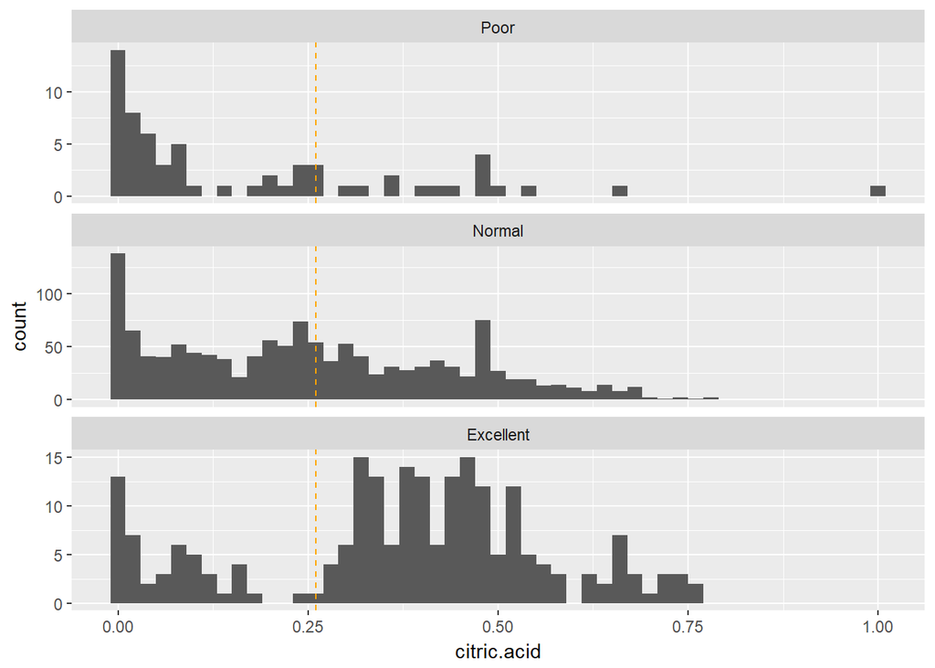

**Observation(s):**  
Excellent wines tend to have citric acid between 0.25 - 0.62 g/dm<sup>3</sup>, above the data set’s median (dashed line) while the lower grade wines tend to have lower citric acid concentration. This is supported by boxplot below.

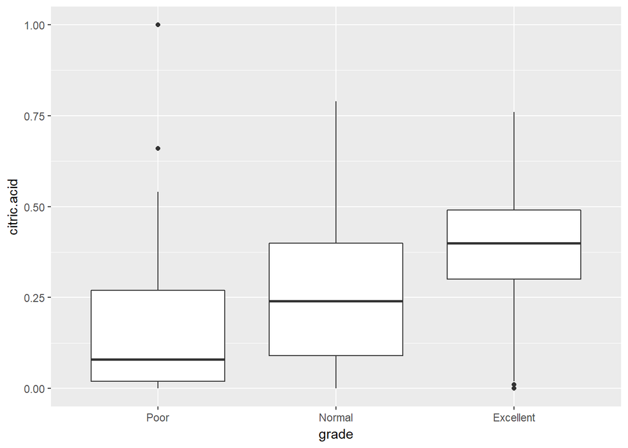

This resonates with me well since acidity of wine is said to be one of its most appealing characteristics according to [Total Wine’s article on acidity & crispness](http://www.totalwine.com/wine-guide/wine-acidity-crispness).

But why then do some Excellent wines have extremely low acidity? Are there other chemical properties making up for this? Higher alcohol? Lower residual sugar? What about sulphates?

According to [Total Wine’s article on balance](http://www.totalwine.com/wine-guide/wine-balance), “Wine high in acid should be balanced with the proper amount of residual sugar.” So, the reverse is true - that wine low in acid should have a counter of residual sugar to create a balance that raises the quality of wine.

### Residual sugar by Grade

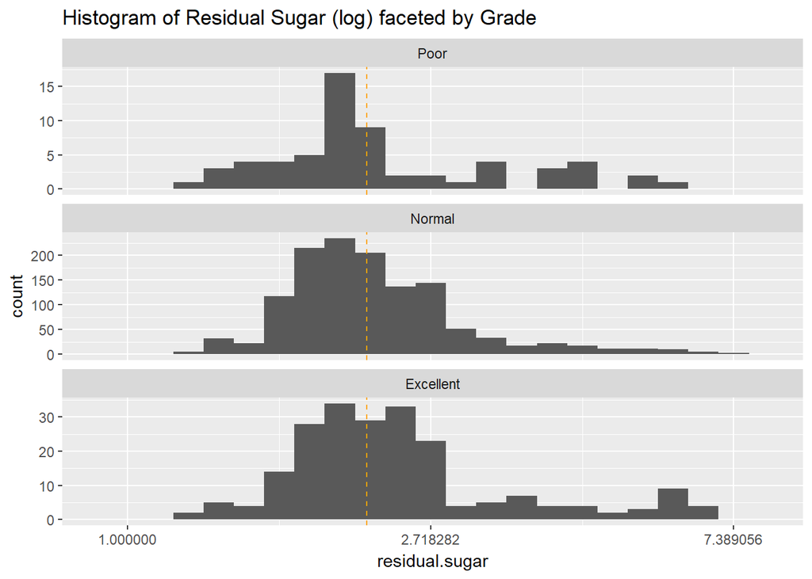

```
##    Min. 1st Qu.  Median    Mean 3rd Qu.    Max.
##   0.900   1.900   2.200   2.539   2.600  15.500
```

**Observation(s):**  
Range bound residual sugar concentration in Normal and Excellent wine at 1.9 - 2.7, around the median value for the data set.

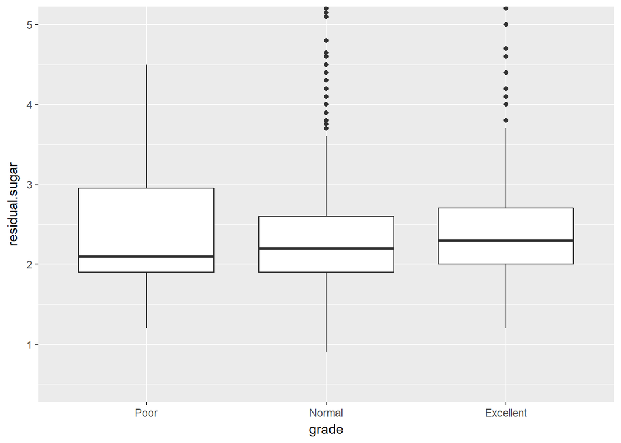

**Observation(s):**  
Range bound residual sugar concentration in Normal and Excellent wine at 1.9 - 2.7, whereas Poor quality wines have wider spread of residual sugar.

So, does residual sugar make up for low citric acid in Excellent wine?

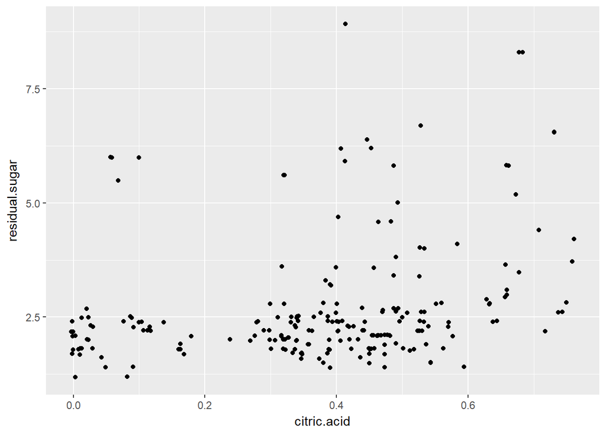

**Observation(s):**  
Excellent wines do not seem to have observable variation in residual sugar concentration for citric acid between 0 - 0.6 g/dm<sup>3</sup>. Residual sugar appears range bound at 1.25 - 2.5 g/dm<sup>3</sup>.

I can see that for citric acid concentration beyond 0.6 g/dm<sup>3</sup>, Excellent wines tend to have higher residual sugar, with levels starting out at 2.4 g/dm<sup>3</sup>.

The table below supports this.

This is rather baffling. One explanation is that citric acid concentration of 0 - 0.6 g/dm<sup>3</sup> is considered “low”, and hence, is balanced with low residual sugar levels. High citric acid concentration starts beyond 0.6 g/dm<sup>3</sup>.

This is counter-intuitive since the scatter plot shows 2 clusters of wine around:

1. citric acid levels of 0 - 0.18 g/dm<sup>3</sup> (which can be construed as “low” or non-fruity)
2. citric acid levels of 0.25 - 0.6 g/dm<sup>3</sup> (which can be construed as “high” or fruity)

```
## # A tibble: 3 x 4
##   citric_cut median_residual_sugar mean_residual_sugar     n
##   <fct>                      <dbl>               <dbl> <int>
## 1 [0,0.2]                     2.20                2.38    45
## 2 (0.2,0.6]                   2.20                2.58   148
## 3 (0.6,0.8]                   3.30                4.10    24
```

### Density vs Citric Acid

What about the ratio of Density to Citric Acid? Does that influence the quality of wine?

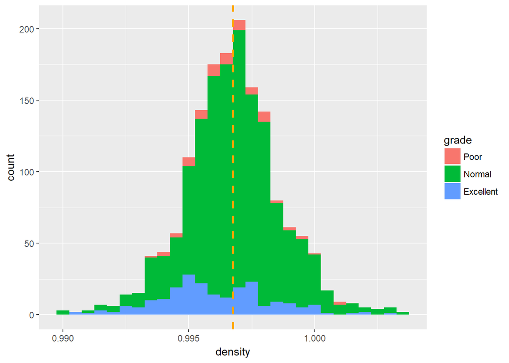

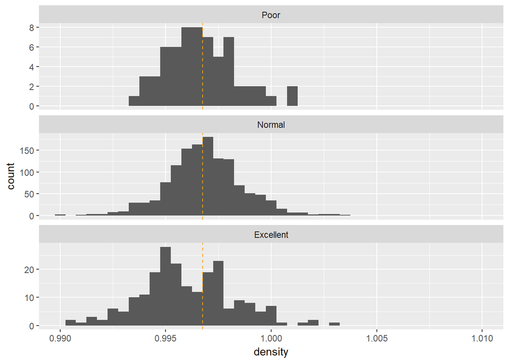

**Observation(s):**  
Multi-modal (bi-modal) distribution of Density in Excellent grade wines - similar to the distribution observed for Citric Acid in wines.